# Depict attributes pertaining to flight departure delays

### by Benjamin UWIMANA MAHUKU

## Investigation Overview

In this investigation, I wanted to look at reasons of delays for flights, how they occur in time and how they connect to unique carriers and airports from which flights originated. The main focus was on following features of a flight: year, month, day of month, day of week, departure delay, carrier delay, weather delay, NAS delay, security delay, late aircraft delay, unique carrier, and origin airport.

## Dataset Overview

This dataset reports flights in the United States, including carriers, arrival and departure delays, and reasons for delays, from 1987 to 2008. The [data](http://stat-computing.org/dataexpo/2009/the-data.html) comes originally from RITA as the website says.  
Given the size of dataset for each year, only three of them (1988, 1998 and 2008) were combined to form single file for this analysis. There are 17,596,545 flights in the clean dataset with 15 features.

## Distribution of departure delays

Departure delays has a wide range of values expressed in number of minutes. It contains some unusually long period of departure delays that go beyond 1500 minutes that are more than 24 hours of delay. I considered those kind of delays as outliers or just canceled flights. Removing extreme values and plotting it gives a right skewed shape portraying how departure delays are diverse.

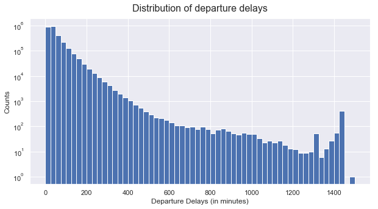

```python
### Removing unusual values of departure delays
flights_clean = flights_clean[flights_clean['DepDelay'] >= 15]
flights_clean = flights_clean[flights_clean['DepDelay'] <= 1500]

# Plotting the variable of interest, 'DepDelay' again
plt.figure(figsize=[10, 5])
bin_edges = np.arange(0, flights_clean['DepDelay'].max()+25, 25)
plt.hist(data = flights_clean, x = 'DepDelay', bins = bin_edges)
plt.title("Distribution of departure delays", fontsize=16, y=1.02)
plt.yscale('log')
plt.xlabel('Departure Delays (in minutes)')
plt.ylabel('Counts')
plt.show()
```

## Categories of departure delays

As departure delays are really diverse, we put them in different categories of delays based on their length as follows:

- less than 30 minutes ==> short
- between 30 and 60 minutes ==> Acceptable
- between 60 and 120 minutes ==> Moderately Long
- between 120 and 180 minutes ==> Long
- between 180 and 240 minutes ==> Very Long
- more than 240 minutes ==> Unusually Very Long.

After assigning the above categories to all departure delays, we see that most of them (almost 70% of all departure delays) are under **short** and **acceptable** categories, while **very long** and **unusually very long** categories, taken together, have 3% of all departure delays.

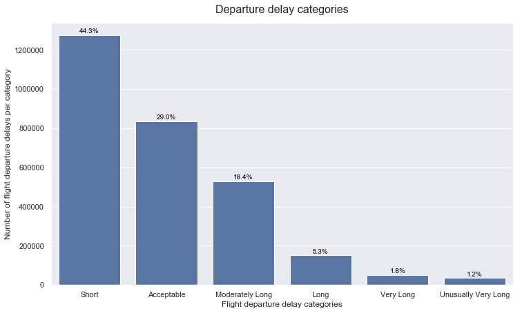

```python
plt.figure(figsize=[12, 7])
catg_order = ["Short", "Acceptable", "Moderately Long", "Long", "Very Long", "Unusually Very Long"]
base_color = sb.color_palette()[0]
sb.countplot(data = flights_clean, x = 'delay_categories' , color = base_color, order = catg_order)

### Adding annotations
n_points = flights_clean.shape[0]
cat_counts = flights_clean['delay_categories'].value_counts()
locs, labels = plt.xticks()

# loop through each pair of locations and labels
for loc, label in zip(locs, labels):
    # get the text property for the label to get the correct count
    count = cat_counts[label.get_text()]
    pct_string = '{:0.1f}%'.format(100*count/n_points)
    plt.text(loc, count+10000, pct_string, ha = 'center', color = 'black')

plt.ylabel('Number of flight departure delays per category')
plt.ylabel('Number of flight departure delays per category')
plt.xlabel('Flight departure delay categories')
plt.title("Departure delay categories", fontsize=16, y=1.02);
```

## Months with largest depature delay rates

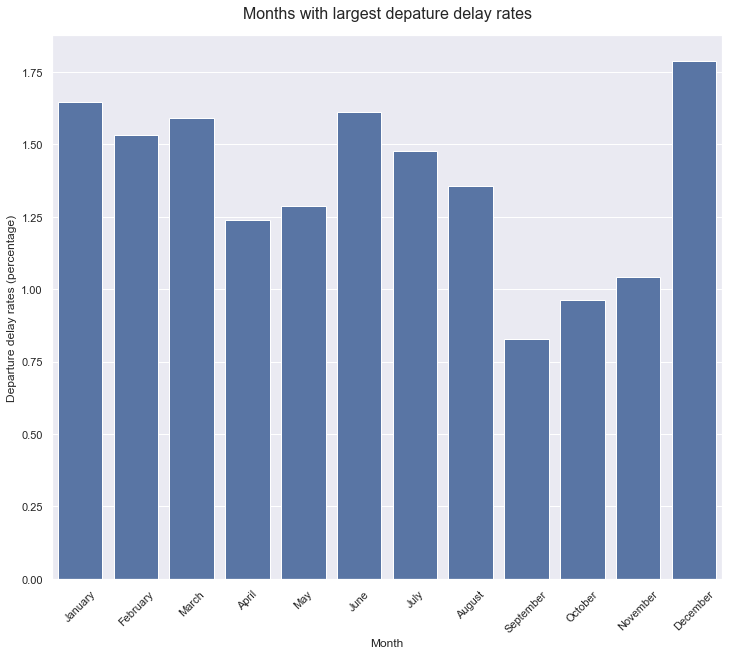

```python
### Plotting 'MonthName' having largest depature delay rates
month_delay_rates = (flights_clean['MonthName'].value_counts()/flights['Month'].shape[0]).sort_values(ascending=False)
month_delay_flight_rates = pd.DataFrame({'Month':month_delay_rates.index, 'delay_rate':month_delay_rates.values})
month_delay_flight_rates['delay_rate'] = month_delay_flight_rates['delay_rate'] * 100
plt.figure(figsize=[12, 10])
plt.xticks(rotation= 45)
base_color = sb.color_palette()[0]
sb.barplot(data = month_delay_flight_rates, x = 'Month', y= 'delay_rate' , color = base_color)
plt.ylabel('Departure delay rates (percentage)')
plt.title('Months with largest depature delay rates', fontsize=16, y=1.02);
```

## Delay reasons vs Departure delay

Plotting flight departure delays and delay reasons (departure delay, carrier delay, weather delay, NAS delay, security delay, and late aircraft delay) shows that only **carrier** and **late aircraft** delay reasons have moderate positive relationship with actual departure delays.

But when we isolate *very long* and *unusually very long* departure delays, we observe that **weather** and **carrier** are most correlated delay reasons with actual departure delays (see plots of this in the longer version of exploration of this dataset).

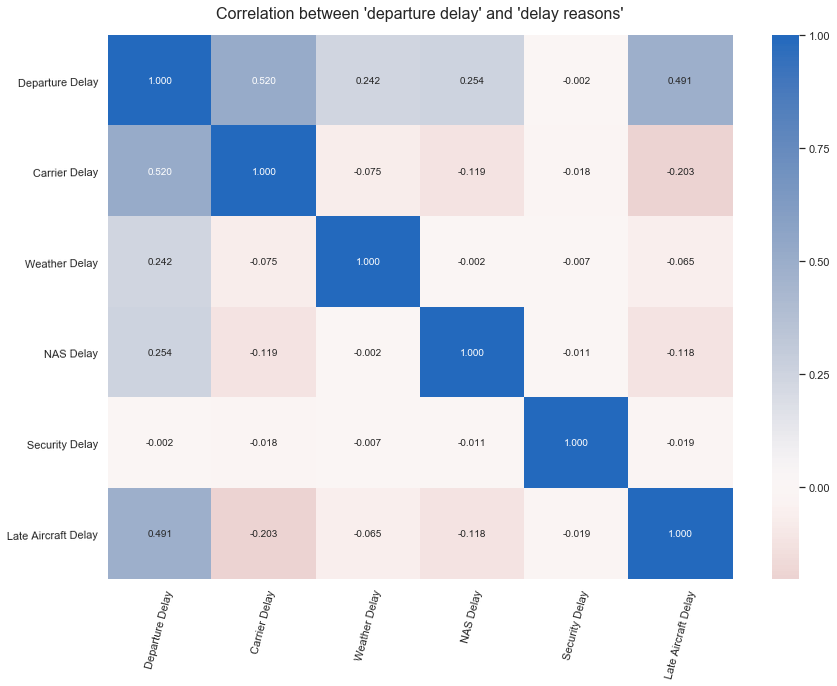

```python
### Making correlation plot
numeric_vars = ['DepDelay', 'CarrierDelay', 'WeatherDelay', 'NASDelay', 'SecurityDelay', 'LateAircraftDelay']
plt.figure(figsize = [14, 10])
axis_ticks = ['Departure Delay', 'Carrier Delay', 'Weather Delay', 'NAS Delay', 'Security Delay', 'Late Aircraft Delay']
sb.heatmap(flights_clean[numeric_vars].corr(), annot = True, fmt = '.3f', cmap = 'vlag_r', center = 0,
          yticklabels = axis_ticks, xticklabels = axis_ticks)
plt.xticks(rotation= 75)
plt.yticks(rotation= 1)
plt.title("Correlation between 'departure delay' and 'delay reasons'", fontsize=16, y=1.02);
plt.show()
```

## Delay categories vs Day of week

The full set of delayed flights shows that Fridays tend to have bigger number of them. But it looks like **very long** and **unusually very long** departure delays are likely to happen evenly on any day of the week. This agrees with the causes of delays which showed strong correlation between these kind of delays and 'Carrier delay' and 'Weather delay' causes of departure delays.

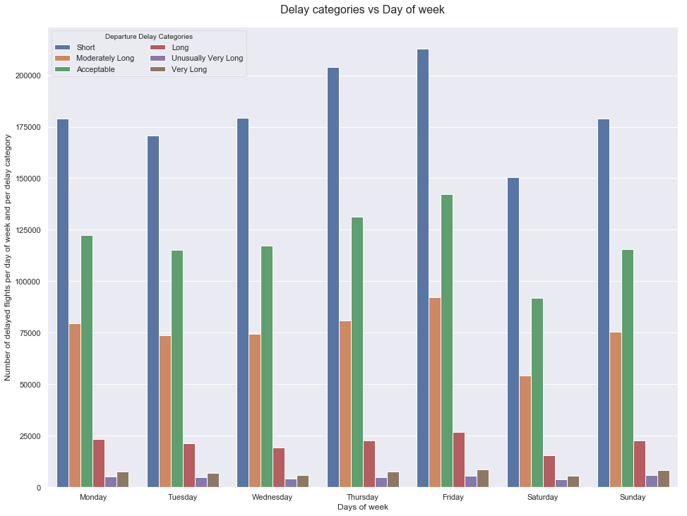

```python
### Plotting relationship between 'delay categories/levels' and days of week on which they occured
plt.figure(figsize=[16, 12])
sb.countplot(data = flights_clean, x = 'DayName', hue = 'delay_categories')
plt.ylabel('Number of delayed flights per day of week and per delay category');
plt.xlabel('Days of week')
plt.title("Delay categories vs Day of week", fontsize=16, y=1.02)
plt.legend(loc = "upper left", title = "Departure Delay Categories", ncol = 2, framealpha = 0.5) ;
```

## Flight departure delays during specific month of year

Of the three selected years, the last two (1998 and 2008) seem to show that we have more departure delays in December and June. This is a confirmation of what we've seen previously, showing that december had highest depature delays among all months throughout the three selected years (1988, 1998 and 2008).

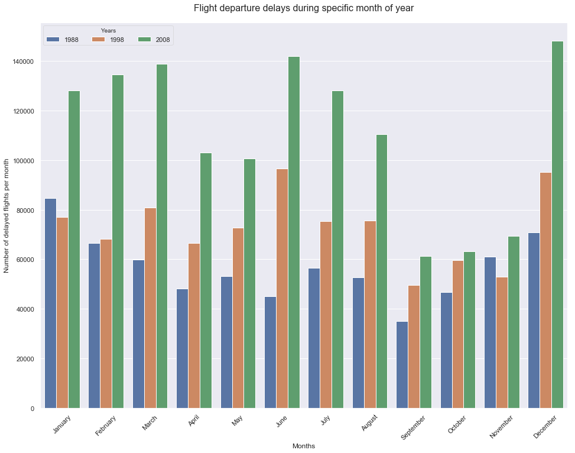

```python
### Checking if more flight delays occured during specific month of year
plt.figure(figsize=[16, 12])
sb.countplot(data = flights_clean, x = 'MonthName', hue = 'Year')
plt.xticks(rotation= 45)
plt.ylabel('Number of delayed flights per month');
plt.xlabel('Months')
plt.title("Flight departure delays during specific month of year", fontsize=16, y=1.02)
plt.legend(loc = "upper left", title = "Years", ncol = 3, framealpha = 0.5);
```

## Magnitude of departure delay reasons

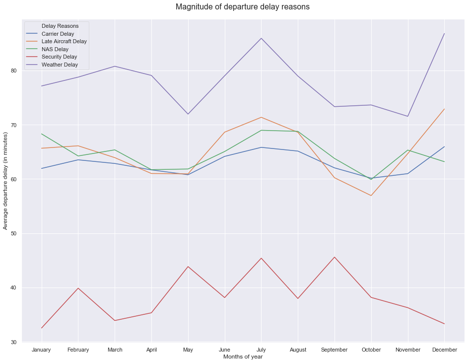

```python
### Use different plot type to check the impact of different reasons of delay on flights departure performance in each month
plt.figure(figsize=[16, 12])
monthly_delay_reason_avg = flights_delay_reasons[['Delay Reasons','MonthName', 'DepDelay']]
monthly_delay_reason_avg = monthly_delay_reason_avg.groupby(
    ['Delay Reasons','MonthName']).agg({'DepDelay': "mean"}).reset_index()
ax = sb.lineplot(data=monthly_delay_reason_avg,x="MonthName", y="DepDelay", hue="Delay Reasons")
plt.xlabel('Months of year')
plt.ylabel('Average departure delay (in minutes)')
plt.title("Magnitude of departure delay reasons", fontsize=16, y=1.02)
plt.legend(loc = "upper left", framealpha = 0.5);
```

## Impact of departure delay reasons on unique carriers

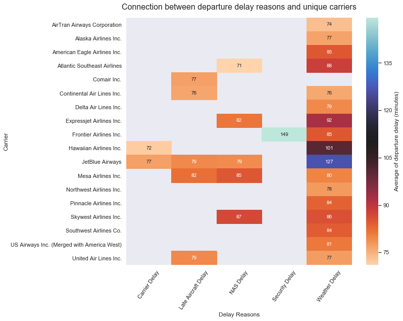

```python
### Checking reasons of delay relate to unique carrier in terms of flights departure delays
plt.figure(figsize=[10, 9])
carrier_delay_reason_avg = flights_delay_reasons[['Delay Reasons','Carrier', 'DepDelay']]
carrier_delay_reason_avg = carrier_delay_reason_avg.groupby(
    ['Delay Reasons','Carrier']).agg({'DepDelay': "mean"}).reset_index()
carrier_delay_reason_avg.sort_values(["DepDelay"],  ascending = False, inplace = True) #
carrier_delay_reason_avg = carrier_delay_reason_avg.head(30)
carrier_delay_reason_avg = carrier_delay_reason_avg.pivot(index = 'Carrier',
                                                                        columns = 'Delay Reasons', values = 'DepDelay')
sb.heatmap(carrier_delay_reason_avg, annot = True, fmt = '.0f', cmap = 'icefire_r',
           cbar_kws = {'label' : 'Average of departure delay (minutes)'})
plt.xticks(rotation= 55)
plt.title("Connection between departure delay reasons and unique carriers", fontsize=16, y=1.02);
```

## Impact of departure delay reasons on origine airports

Again for visibility sake, we'll look at first 30 longest departure delays. Same trend of relationship between unique carriers and reasons of departure delays is observed also between origin airports and departure delay reasons. Still **weather** and **carrier** delay reasons are affecting most airports than other reasons of departure delays.

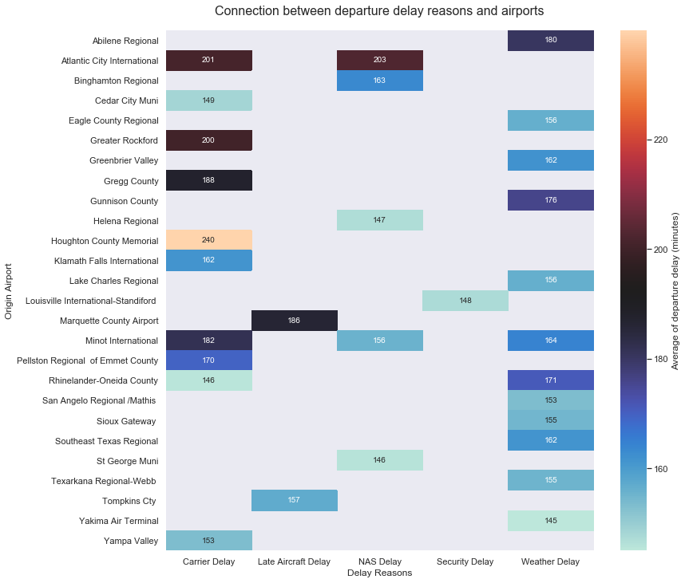

```python
plt.figure(figsize=[12, 12])
origin_airport_delay_reason_avg = flights_delay_reasons[['Delay Reasons','OriginAirport', 'DepDelay']]
origin_airport_delay_reason_avg = origin_airport_delay_reason_avg.groupby(
    ['Delay Reasons','OriginAirport']).agg({'DepDelay': "mean"}).reset_index()
origin_airport_delay_reason_avg.sort_values(["DepDelay"],  ascending = False, inplace = True)
origin_airport_delay_reason_avg = origin_airport_delay_reason_avg.head(30)
origin_airport_delay_reason_avg = origin_airport_delay_reason_avg.pivot(index = 'OriginAirport',
                                                                        columns = 'Delay Reasons', values = 'DepDelay')

sb.heatmap(origin_airport_delay_reason_avg, annot = True, fmt = '.0f', cmap = 'icefire',
           cbar_kws = {'label' : 'Average of departure delay (minutes)'})
plt.ylabel('Origin Airport')
plt.title("Connection between departure delay reasons and airports", fontsize=16, y=1.02);
```